# FP2–V1. Napetost površine

## Matija Pajas

### Zadatak 1

Odredite površinsku napetost destilirane vode na sobnoj temperaturi metodom otkidanja. Promjer prstena je $2r = 19,65 \ \mathrm{mm}$ (svakako provjerite mjerenjem!).

Prije mjerenja za ovaj zadatak bilo je potrebno baždariti dinamometar na nulu okretanjem vijka. Bitno je da su prsten i vrpca na kojoj visi suhi prije baždarenja, a time smo uklonili težinu prstena. Mjerenje se izvodi tako da se prsten uroni u vodu koja se nakon toga polako odvodi, a dinamometar istovremeno okreće tako da poluga ostane na nultom položaju sve dok prsten ne iskoči. Mjesto na kojem se dinamometar sada nalazi se očita. Podaci mjerenja nalaze se u tablici niže.

|  | $F_\mathrm{n}$ / $\mathrm{mN}$ |
| --- | --- |
| 1 | 4,50 |
| 2 | 4,20 |
| 3 | 4,25 |
| 4 | 4,30 |
| 5 | 4,40 |
| 6 | 4,35 |
| 7 | 4,50 |
| 8 | 4,30 |
| 9 | 4,35 |
| 10 | 4,40 |

Iz izmjerenih podataka izračunata je srednja vrijednost i nepouzdanost te je sila:

$$F_\mathrm{n} = (4,3549999999999995 \pm 0,031135902820449014) \times 10^{-3} \ \mathrm{N} $$

$$F_\mathrm{n} = (4,35 \pm 0,03) \times 10^{-3} \ \mathrm{N} $$

Napetost površine računamo izrazom

$$\gamma = \frac{F_\mathrm{n}}{l} = \frac{F_\mathrm{n}}{4r\pi} $$

no prije toga potrebno je izračunati nepouzdanost radijusa i radijus. Promjer je izmjeren uz procijenjenu nepouzdanost $d = 19,6 \pm 0,1 \ \mathrm{mm}$.

Radijus je dan izrazom

$$r = \frac{d}{2} = 9,8 \ \mathrm{mm}$$

te njegova nepouzdanost

$$ M_r=\sqrt{ \left ( \frac{\partial r}{\partial d} M_d \right )^2 }= \left | \frac{M_d}{2} \right | = \frac{M_d}{2} = 0,05 \ \mathrm{mm} $$

Ovim podacima može se sada izračunati nepouzdanost izraza za napetost površine koja glasi

$$ \begin{align} M_\gamma &=\sqrt{ \left ( \frac{\partial \gamma}{\partial F_\mathrm{d}} M_{F_\mathrm{d}}\right )^2+ \left ( \frac{\partial \gamma}{\partial r} M_{r}\right )^2}\\ M_\gamma &= \sqrt{ \left ( \frac{1}{4r\pi} M_{F_\mathrm{d}}\right )^2+ \left (- \frac{F_\mathrm{d}}{4r^2 \pi} M_r\right )^2 } \\ M_\gamma &= \sqrt{ \left ( \frac{F_\mathrm{d}}{4r\pi} \cdot \frac{M_{F_\mathrm{d}}}{F_\mathrm{d}}\right )^2+ \left ( \frac{F_\mathrm{d}}{4r \pi} \cdot \frac{M_r}{r}\right )^2 } \\M_\gamma &=\gamma \cdot \sqrt{ \left ( \frac{M_{F_\mathrm{d}}}{F_\mathrm{d}}\right )^2+ \left ( \frac{M_r}{r}\right )^2 }= 0,0003033689997247447 \ \mathrm{\frac{N}{m}} \end{align} $$

Te na kraju ukupan rezultat glasi

$$\gamma = (0,035363253937000204 \pm 0,0003033689997247447) \ \mathrm{\frac{N}{m}}$$

### Rezultat:

$$\gamma = (35,4 \pm 0,3) \times 10^{-3} \ \mathrm{\frac{N}{m}}$$

### Zadatak 2

Izmjerite pripadnu temperaturnu ovisnost površinske napetosti. Nacrtajte $T − \gamma$ graf te metodom najmanjih kvadrata odredite temperaturni koeficijent $k_\gamma$ i temperaturu $T_\mathrm{K}$. Molarni volumen vode iznosi $V_\mathrm{m} = 18 \ \mathrm{{cm}^3}$.

Postupak mjerenja je identičan kao u prethodnome zadatku, no ovdje se voda grijala do $90 \ \mathrm{°C}$, a mjerenja se izvode kako se voda hladi u što više točaka kako bi se pronašla ovisnost napetosti površine vode o temperaturi. Trebalo je paziti da se vodu ne grije prebrzo kako ne bi zaključala. Mjerenja se mogu pronaći u tablici niže.

|  | $T$ / $\mathrm{°C}$ | $T$ / $\mathrm{K}$ | $F_\mathrm{n}$ / $\mathrm{mN}$ | $\gamma$ / $\mathrm{N/m}$ |
| --- | --- | --- | --- | --- |
| 1 | 91 | 364,15 | 3,20 | 0,025984 |
| 2 | 86 | 359,15 | 3,10 | 0,025172 |
| 3 | 84 | 357,15 | 3,15 | 0,025578 |
| 4 | 79 | 352,15 | 3,20 | 0,025984 |
| 5 | 75 | 348,15 | 3,20 | 0,025984 |
| 6 | 71 | 344,15 | 3,30 | 0,026796 |
| 7 | 67 | 340,15 | 3,35 | 0,027203 |
| 8 | 62 | 335,15 | 3,40 | 0,027609 |
| 9 | 58 | 331,15 | 3,45 | 0,028015 |
| 10 | 54 | 327,15 | 3,60 | 0,029233 |
| 11 | 49 | 322,15 | 3,50 | 0,028421 |
| 12 | 46 | 319,15 | 3,60 | 0,029233 |
| 13 | 44 | 317,15 | 3,65 | 0,029639 |
| 14 | 40 | 313,15 | 3,80 | 0,030857 |
| 15 | 37 | 310,15 | 3,80 | 0,030857 |

Kako bi se odredili $T_\mathrm{K}$ i $k_\gamma$ koristi se idući izraz koji prepoznajemo kao jednadžbu pravca te sa podacima iz tablice iznad provodi se metoda najmanjih kvadrata.

$$\gamma(T)=-\gamma_0 T+\gamma_0 T_K$$

Ako je jednadžba pravca $y=ax+b$, tada su

$$ \begin{align} y&=\gamma \\ x&=T \\ a&=-\gamma_0 \\ b&=\gamma_0 T_K\\ \end{align} $$

Prije nego krenemo sa računanjem podataka, prepoznajmo potrebne izraze i njihove nepouzdanosti:

### Izraz i nepouzdanost za $\gamma_0$

$$\gamma_0=-a$$

$$ M_{\gamma_0}=\sqrt{\left ( \frac{\partial \gamma_0}{\partial a} M_{a}\right )^2}= \sqrt{\left ( - M_{a}\right )^2}=\left | -M_{a} \right | = M_{a} $$

### Izraz i nepouzdanost za $T_\mathrm{K}$

$$ T_K=\frac{b}{\gamma_0} $$

$$ \begin{align} M_{T_K}&=\sqrt{\left ( \frac{\partial T_K}{\partial b} M_{b}\right )^2+ \left ( \frac{\partial T_K}{\partial \gamma_0} M_{\gamma_0}\right )^2 }\\M_{T_K}&= \sqrt{ \left ( \frac{1}{\gamma_0} M_{b}\right )^2+ \left (- \frac{b}{ \gamma_0^2} M_{\gamma_0}\right )^2 }\\M_{T_K}&= \sqrt{ \left ( \frac{b}{\gamma_0} \cdot \frac{M_{b}}{b}\right )^2+ \left ( \frac{b}{ \gamma_0} \cdot \frac{M_{\gamma_0}}{\gamma_0}\right )^2 }\\M_{T_K}&= T_K \cdot \sqrt{ \left ( \frac{M_{b}}{b}\right )^2+ \left ( \frac{M_{\gamma_0}}{\gamma_0}\right )^2 } \end{align} $$

### Izraz i nepouzdanost za $k_\gamma$

$$k_\gamma=\gamma_0V_m^{2/3}$$

gdje je $V_m = 18 \times 10^{-6} \ \mathrm{m^3}$ te se tretira kao konstanta.

$$ \begin{align} M_{k_\gamma}&=\sqrt{\left ( \frac{\partial k_\gamma}{\partial \gamma_0} M_{\gamma_0}\right )^2} \\M_{k_\gamma}&=\sqrt{\left (V_m^{2/3} \cdot M_{\gamma_0}\right )^2} \\M_{k_\gamma}&=\sqrt{\left ( \gamma_0 V_m^{2/3} \cdot \frac{M_{\gamma_0}}{\gamma_0}\right )^2}=k_{\gamma} \cdot \frac{M_{\gamma_0}}{\gamma_0} \end{align} $$

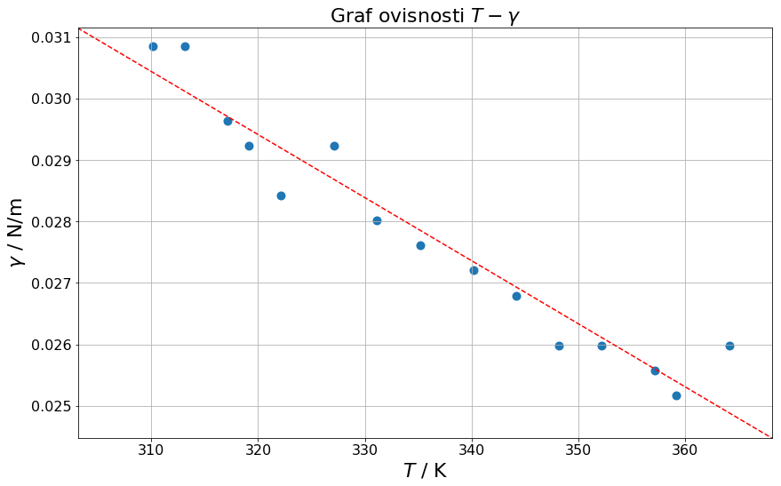

### Rezultat metode najmanjih kvadrata

$a = (-0,00010263590646685444 \pm 0,000007777263325090237) \ \mathrm{\frac{N}{Km}}$

$a = (-103 \pm 8) \times 10^{-6} \ \mathrm{\frac{N}{Km}}$

$b = (0,06225828871081196 \pm 0,0026166762000309936) \ \mathrm{\frac{N}{m}}$

$b = (0,062 ± 0,003) \ \mathrm{\frac{N}{m}}$

Te se sada prepoznaju ili izračunaju tražene veličine. Prvo se prepoznaje $\gamma_0$

$$\gamma_0 = (0,103 \pm 0,008) \times 10^{-3} \ \mathrm{\frac{N}{Km}}$$

nakon čega se može izračunati $T_\mathrm{K}$ i njegova nepouzdanost

$$ T_K=\frac{b}{\gamma_0} = 601,9417475728155 \ \mathrm{K}$$

$$M_{T_K}= 55,08317904787849 \ \mathrm{K}$$

te $k_\gamma$ i njegova nepouzdanost

$$k_\gamma=\gamma_0V_m^{2/3} = 7,074334018979595 \times 10^{-8} \ \mathrm{\frac{J}{K}} $$

$$M_{k_\gamma} = 5,494628364255997 \times 10^{-9} \ \mathrm{\frac{J}{K}}$$

### Rezultati:

$\gamma_0 = (0,103 \pm 0,008) \times 10^{-3} \ \mathrm{\frac{N}{Km}}$

$T_K = (600 \pm 60) \ \mathrm{K} $

$k_\gamma = (0,71 \pm 0,05) \times 10^{-7} \ \mathrm{\frac{J}{K}} $

### Zadatak 3

Izmjerite površinsku napetost destilirane vode na sobnoj temperaturi pomoću kapilarnog efekta. Izračunajte opću srednju vrijednost. Promjeri kapilara jesu $(3,0 ± 0,1) \ \mathrm{mm}$; $(2,2 ± 0,1) \ \mathrm{mm}$; $(1,5 ± 0,1) \ \mathrm{mm}$; $(0, 8 ± 0, 1) \ \mathrm{mm}$. Za svaki slučaj, to provjerite mjerenjem jer se često lome pa mogu biti zamijenjene kapilarama novih dimenzija.

Za ovaj zadatak bilo je potrebno izmjeriti visinu tekućine $h$ za četiri različite kapilare. Za $h$ je procijenjena nepouzdanost $M_h = 1 \ \mathrm{mm}$, a za radijus kapilare $r$ je dobivena na jednak način kao u zadatku (1) te iznosi $M_r = 0.05 \ \mathrm{mm}$. Uz te podatke potrebni su još i $g=9,81 \ \mathrm{\frac{m}{s^2}}$ i $\rho=998,23 \ \mathrm{\frac{kg}{m^2}}$ koji se tretiraju kao konstante.

Izraz koji se koristi za računanje napetosti površine, izveden u pripremi vježbe, glasi:

$$\gamma=\frac{1}{2}r \rho gh(1+\frac{r}{3h})$$

te je njegova pripadna nepouzdanost

$$ \begin{align} M_{\gamma}&=\sqrt{ \left ( \frac{\partial \gamma}{\partial r}M_r \right )^2 + \left ( \frac{\partial \gamma}{\partial h} M_h \right )^2 } \\ M_{\gamma}&=\sqrt{ \left ( \left ( \frac{1}{2} \rho g h + \frac{1}{3}r \rho g \right )M_r \right )^2 + \left ( \frac{1}{2}r \rho g M_h \right )^2} \end{align} $$

Za svaku kapilaru nadodani su u tablicu podataka izračunati iznosi napetosti površine uz nepouzdanosti za pripadnu kapilaru.

|  | $r$ / $\mathrm{m}$ | $h$ / $\mathrm{m}$ | $\gamma$ / $\mathrm{N/m}$ | $M_\gamma$ / $\mathrm{N/m}$ |
| --- | --- | --- | --- | --- |
| 1 | 0,00150 | 0,007 | 0,055084 | 0,007600 |
| 2 | 0,00110 | 0,005 | 0,028905 | 0,005565 |
| 3 | 0,00075 | 0,015 | 0,056002 | 0,005280 |
| 4 | 0,00040 | 0,025 | 0,049224 | 0,006488 |

Da bi se izračunala srednja vrijednost napetosti površine iz prethodnih podataka potrebno je koristiti poopćeni prosjek uz pripadne težine svakog rezultata izrazima koji se nalaze u uputama za obradu mjerenja.

### Rezultat

$$\gamma = (0,04637271038333244 \pm 0,0030257403968329036) \ \mathrm{\frac{N}{m}}$$

$$\gamma = (46 \pm 3) \times 10^{-3} \ \mathrm{\frac{N}{m}}$$

### Zaključak

#### Zadatak 1

Tablični podatak za iznos površinske napetosti vode je $\gamma = 72.80 \times 10^{-3} \ \mathrm{\frac{N}{m}}$ dok je izmjereni $\gamma = (35,4 \pm 0,3) \times 10^{-3} \ \mathrm{\frac{N}{m}}$ što je gotovo pola. Razlog tomu je što je prsten visio pod kutem te se stol često tresao prilikom mjerenja. U mirnijim uvjetima rezultat bi ispao puno precizniji.

#### Zadatak 2

Tablični podatak za temperaturni koeficijent je $\gamma_0 = 0.1514 \times 10^{-3} \ \mathrm{\frac{N}{Km}}$ dok je izmjereni $\gamma_0 = (0,103 \pm 0,008) \times 10^{-3} \ \mathrm{\frac{N}{Km}}$ koji je puno bliži tabličnoj vrijednosti nego prethodni zadatak. Već je samo mjerenje sa vrućom vodom bilo dovoljno turbulentno, tako da su se spomenute smetnje iz prvog zadatka "prigušile". Osim toga treba primijetiti kako je dobiveni $k_\gamma = (0,71 \pm 0,05) \times 10^{-7} \ \mathrm{\frac{J}{K}} < 2,1 \times 10^{-7} \ \mathrm{\frac{J}{K}}$ što sugerira da molekule vode asociraju s porastom temperature.